# Credit Risk Stress Testing in R

This project includes stress testing, credit risk modeling, and capital impact analysis using macroeconomic scenarios on a loan portfolio.

2025-06-15

### Overview

This project implements a stress testing framework combining macroeconomic scenario simulation, credit risk modeling, and capital impact analysis, using real-world French economic data. The analysis demonstrates how adverse economic conditions affect a loan portfolio’s expected losses and regulatory capital adequacy.

### Data and Sources

GDP, Unemployment, Inflation: Quarterly data from Eurostat, covering France.

Data cleaning includes calculating GDP growth rates, quarterly unemployment rates, and inflation.

Historical macroeconomic data is used to fit a Vector Autoregression (VAR) model for scenario simulation.

### Install and import packages

```r
# if not installed:
# install.packages(c("tidyverse", "vars", "eurostat", "zoo", "dplyr"))

library(tidyverse)
library(vars)
library(eurostat)
library(zoo)
library(dplyr)
```

### Set up parameters

```r
gdp_shock_size <- 2
unemp_shock_size <- 1
infl_shock_size <- 1.5
n_quarters <- 8

n_credits <- 1000

CET1_initial <- 1000
RWA <- 10000
```

### Download data

```r
# GDP
# search_eurostat("gdp france quarterly")
gdp_raw <- get_eurostat("namq_10_gdp", filters = list(
  geo = "FR",
  na_item = "B1GQ",
  unit = "CLV10_MEUR"
))
```

```r
# Unemployment
unemp_raw <- get_eurostat("une_rt_q", filters = list(
  geo = "FR",
  sex = "T",
  age = "Y20-64",
  unit = "PC_ACT"
))
# Inflation
inflation_raw <- get_eurostat("prc_hicp_midx", filters = list(
  geo = "FR",
  coicop = "CP00",
  unit = "I15"
))
```

### Clean data

```r
# GDP : growth rate
gdp_q <- gdp_raw %>%
  arrange(time) %>%
  mutate(
    time = as.yearqtr(time),
    gdp_growth = 100 * (values / lag(values) - 1)) %>%
  filter(!is.na(gdp_growth)) %>%
  dplyr::select(time, gdp_growth)

gdp_q_unique <- gdp_q %>%
  group_by(time) %>%
  summarise(gdp_growth = mean(gdp_growth, na.rm = TRUE))


# Unemployment rate
unemp_q <- unemp_raw %>%
  dplyr::select(time, unemployment_rate = values) %>%
  arrange(time) %>%
  filter(!is.na(unemployment_rate)) %>%
  mutate(time = as.yearqtr(time))

unemp_q_unique <- unemp_q %>%
  group_by(time) %>%
  summarise(unemployment = mean(unemployment_rate, na.rm = TRUE))


# Inflation
# Convert monthly index to quarterly average index
inflation_q <- inflation_raw %>%
  mutate(quarter = as.yearqtr(time)) %>%
  group_by(quarter) %>%
  summarise(avg_index = mean(values, na.rm = TRUE)) %>%
  arrange(quarter) %>%
  # Compute quarter-on-quarter inflation rate in %
  mutate(inflation = 100 * (avg_index / lag(avg_index) - 1)) %>%
  filter(!is.na(inflation))

inflation_q <- inflation_q %>%
  rename(time = quarter) %>%
  dplyr::select(time, inflation)


# Merge
macro_data <- gdp_q_unique %>%
  inner_join(unemp_q_unique, by = "time") %>%
  inner_join(inflation_q, by = "time") %>%
  arrange(time)


# For later: Assuming that initial GDP level is the last observed GDP level from the original data
last_gdp_level <- as.numeric(tail(gdp_raw$values, 1))

macro_data <- macro_data %>%
  mutate(GDP_level = last_gdp_level * cumprod(1 + gdp_growth / 100))
```

### Vector Autoregression VAR(1) model

A VAR model on GDP growth, unemployment, and inflation to capture dynamic relationships and forecast future quarters.

```r
# Time series matix
macro_ts <- macro_data %>%
  dplyr::select(gdp_growth, unemployment, inflation) %>%
  as.matrix()

# Fit model
var_model <- VAR(macro_ts, p = 1, type = "const")
summary(var_model)
```

```
##
## VAR Estimation Results:
## =========================
## Endogenous variables: gdp_growth, unemployment, inflation
## Deterministic variables: const
## Sample size: 88
## Log Likelihood: -199.379
## Roots of the characteristic polynomial:
## 0.9622 0.2606 0.215
## Call:
## VAR(y = macro_ts, p = 1, type = "const")
##
##
## Estimation results for equation gdp_growth:
## ===========================================
## gdp_growth = gdp_growth.l1 + unemployment.l1 + inflation.l1 + const
##
##                 Estimate Std. Error t value Pr(>|t|)
## gdp_growth.l1   -0.26162    0.10647  -2.457   0.0161 *
## unemployment.l1  0.05025    0.13628   0.369   0.7132
## inflation.l1     0.23012    0.22693   1.014   0.3135
## const           -0.31933    1.18925  -0.269   0.7890
## ---
## Signif. codes:  0 '***' 0.001 '**' 0.01 '*' 0.05 '.' 0.1 ' ' 1
##
##
## Residual standard error: 1.12 on 84 degrees of freedom
## Multiple R-Squared: 0.0733,  Adjusted R-squared: 0.0402
## F-statistic: 2.215 on 3 and 84 DF,  p-value: 0.09238
##
##
## Estimation results for equation unemployment:
## =============================================
## unemployment = gdp_growth.l1 + unemployment.l1 + inflation.l1 + const
##
##                 Estimate Std. Error t value Pr(>|t|)
## gdp_growth.l1   -0.09941    0.02713  -3.665 0.000433 ***
## unemployment.l1  0.94586    0.03472  27.242  < 2e-16 ***
## inflation.l1    -0.10446    0.05782  -1.807 0.074374 .
## const            0.50552    0.30300   1.668 0.098964 .
```

[output cut: 24 more lines]

```
## F-statistic:  4.35 on 3 and 84 DF,  p-value: 0.006728
##
##
##
## Covariance matrix of residuals:
##              gdp_growth unemployment inflation
## gdp_growth      1.25469      0.13320   0.03814
## unemployment    0.13320      0.08145  -0.05403
## inflation       0.03814     -0.05403   0.30510
##
## Correlation matrix of residuals:
##              gdp_growth unemployment inflation
## gdp_growth      1.00000       0.4167   0.06165
## unemployment    0.41667       1.0000  -0.34276
## inflation       0.06165      -0.3428   1.00000
```

- **Unemployment** is highly persistent (strong AR coefficient, R²=0.92) and strongly influenced by past GDP growth (negative, significant).
- **GDP Growth** shows weak predictability (low R²), with only its own lag being significant.
- **Inflation** is somewhat persistent and negatively linked to unemployment, but overall model fit is low.
- **Residuals**: Moderate correlation between GDP and unemployment, negative between unemployment and inflation.
- **Stress Testing Implication**: Shocks to unemployment are likely to last, and GDP downturns will increase unemployment. Inflation dynamics are less reliable in this model.

### Simulate macro paths

Generate baseline and stressed macroeconomic paths. The stress scenario applies potential shocks to GDP (-2%), unemployment (+1%), and inflation (+1.5%), decreasing exponentially over time.

```r
# Baseline:
set.seed(123)
sim_base <- predict(var_model, n.ahead = n_quarters)

gdp_sim <- sim_base$fcst$gdp_growth[,1]
unemp_sim <- sim_base$fcst$unemployment[,1]
infl_sim <- sim_base$fcst$inflation[,1]

sim_data <- tibble(
  quarter = 1:n_quarters,
  scenario = "baseline",
  gdp_growth = gdp_sim,
  unemployment = unemp_sim,
  inflation = infl_sim
)

sim_data <- sim_data %>%
  group_by(scenario) %>%
  mutate(GDP_level = last_gdp_level * cumprod(1 + gdp_growth / 100)) %>%
  ungroup()

# Stressed:
gdp_stress <- numeric(n_quarters)
unemp_stress <- numeric(n_quarters)
infl_stress <- numeric(n_quarters)
# Apply shocks at quarter 1
for (i in 1:n_quarters) {
  gdp_stress[i] <- gdp_sim[i] - gdp_shock_size * exp(-0.3 * (i - 1))
  unemp_stress[i] <- unemp_sim[i] + unemp_shock_size * exp(-0.3 * (i - 1))
  infl_stress[i] <- infl_sim[i] + infl_shock_size * exp(-0.3 * (i - 1))
}

sim_data_stress <- tibble(
  quarter = 1:n_quarters,
  scenario = "stress",
  gdp_growth = gdp_stress,
  unemployment = unemp_stress,
  inflation = infl_stress
)

sim_data_stress <- sim_data_stress %>%
  group_by(scenario) %>%
  mutate(GDP_level = last_gdp_level * cumprod(1 + gdp_growth / 100)) %>%
  ungroup()


# Merge
sim_all <- bind_rows(sim_data, sim_data_stress)
```

### Visualize macro paths

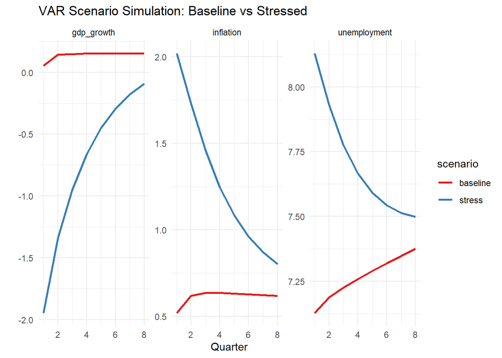

```r
sim_all %>%
  pivot_longer(cols = c(gdp_growth, unemployment, inflation), names_to = "variable", values_to = "value") %>%
  ggplot(aes(x = quarter, y = value, color = scenario)) +
  geom_line(size = 1) +
  facet_wrap(~variable, scales = "free_y") +
  theme_minimal() +
  scale_color_brewer(palette = "Set1") +
  labs(title = "VAR Scenario Simulation: Baseline vs Stressed", y = "", x = "Quarter")
```

### Simulate a loan portfolio

Simulation of a synthetic loan portfolio with Exposure at Default (EAD), Loss Given Default (LGD), and sector assignments.

```r
set.seed(123) # ensure the random numbers are reproducible

portfolio <- tibble(
  id = 1:n_credits,
  sector = sample(c("Industry", "Services", "Construction"), n_credits, replace = TRUE), #randomly assign a sector to each loan
  EAD = runif(n_credits, 100000, 1000000), #exposure at default
  LGD = runif(n_credits, 0.2, 0.5) #loss given default
)
```

### Simulate macroeconomic data for PD model

Note: The Probability of Default model is based on synthetic training data for illustrative purposes. Real-world calibration would require actual default histories.

```r
set.seed(456)
gdp_growth_train <- rnorm(40, mean = 0.5, sd = 1)

macro_data_pd <- tibble(
  quarter = 1:40,
  GDP = gdp_growth_train,
  unemployment = 8 + cumsum(rnorm(40, 0, 0.2)),
  inflation = 1.5 + cumsum(rnorm(40, 0, 0.1)),
  default_rate = 0.02 + 0.005 * (0.5 - GDP) + 0.01 * (unemployment - 8) + rnorm(40, 0, 0.002)
)
```

### Probability of Default model

A Probability of Default (PD) model linking macroeconomic variables to default rates using logistic regression.

```r
# Probability of default (PD) as a function of macro variables
macro_data_pd <- macro_data_pd %>%
  mutate(default_flag = ifelse(default_rate > median(default_rate), 1, 0))
# 1 if default rate above median, 0 otherwise

model_pd <- glm(default_flag ~ GDP + unemployment + inflation, data = macro_data_pd, family = binomial)
# fits a generalized linear model
```

### Predict PD for each macro path

```r
sim_all <- sim_all %>%
  mutate(GDP = gdp_growth)

sim_all <- sim_all %>%
  mutate(
    PD_sim = predict(
      model_pd,
      newdata = tibble(GDP = GDP, unemployment = unemployment, inflation = inflation),
      type = "response"
    ),
  )
```

### Expand portfolio and compute losses

Calculation of expected losses by sector and quarter, adjusting PD by sector risk premiums.

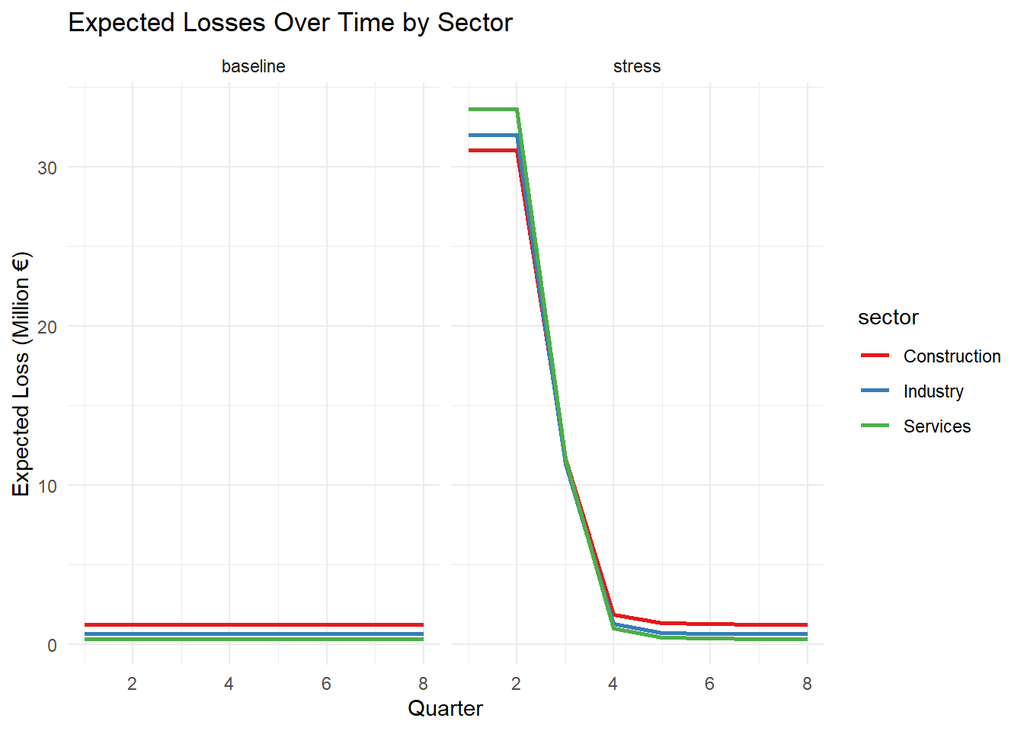

```r
portfolio_expanded <- sim_all %>%
  dplyr::select(scenario, quarter, PD_sim) %>%
  crossing(portfolio) %>%
  mutate(
    sector_adj = case_when(
      sector == "Industry" ~ 0.01,
      sector == "Services" ~ 0.005,
      sector == "Construction" ~ 0.02,
      TRUE ~ 0
    ),
    PD_sim = pmin(PD_sim + sector_adj, 0.5), # makes sure PD does not exceed 50%
    Expected_Loss = PD_sim * LGD * EAD
  )

# Losses by quarter
losses_by_sector_quarter <- portfolio_expanded %>%
  group_by(scenario, quarter, sector) %>%
  summarise(Total_Loss = sum(Expected_Loss)/1e6, .groups = "drop")

ggplot(losses_by_sector_quarter, aes(x = quarter, y = Total_Loss, color = sector)) +
  geom_line(size = 1) +
  facet_wrap(~scenario) +
  theme_minimal() +
  scale_color_brewer(palette = "Set1") +
  labs(title = "Expected Losses Over Time by Sector",
       x = "Quarter", y = "Expected Loss (Million €)")
```

This highlights the importance of capital buffers to absorb losses during severe downturns and the systemic nature of macro shocks.

### Solvency impact

Assessment of the impact of stressed losses on CET1 capital and capital adequacy ratios, assuming initial capital and risk-weighted assets.

```r
final_losses_stress <- losses_by_sector_quarter %>%
  filter(scenario == "stress") %>%
  summarise(total = sum(Total_Loss)) %>%
  pull(total)

CET1_final <- CET1_initial - final_losses_stress
CET1_ratio <- CET1_final / RWA
CET1_ratio_pct <- CET1_ratio * 100

print(paste0("Total expected stress loss: ", round(final_losses_stress,1), "M€"))
```

```
## [1] "Total expected stress loss: 241.3M€"
```

```r
if (final_losses_stress > CET1_initial) {
  warning("⚠️ Losses exceed CET1 — check calibration.")
}

print(paste0("Final CET1: ", round(CET1_final, 1), "M€"))
```

```
## [1] "Final CET1: 758.7M€"
```

```r
print(paste0("CET1 ratio under stress: ", round(CET1_ratio_pct, 2), " %"))
```

```
## [1] "CET1 ratio under stress: 7.59 %"
```

```r
capital_buffer_pct <- (CET1_final / CET1_initial) * 100
print(paste0("Capital buffer remaining under stress: ", round(capital_buffer_pct, 2), "%"))
```

```
## [1] "Capital buffer remaining under stress: 75.87%"
```

```r
print(paste0("Capital buffer consumed under stress: ", round(100 - capital_buffer_pct, 2), "%"))
```

```
## [1] "Capital buffer consumed under stress: 24.13%"
```

- **CET1 ratio under stress** (7.59%) remains above the minimum regulatory requirement (4.5% or 7% including buffer)
- **Capital buffer remaining** of 75.87%), indicating resilience.

Although losses are significant, the CET1 ratio stays above regulatory minimums, and most of the capital buffer remains intact. This suggests a solid capital position and the ability to absorb severe macroeconomic shocks without breaching regulatory thresholds.

### Limitations

- The PD model is synthetic and illustrative; real default data would improve accuracy.
- Scenario shocks and decay rates can be refined with expert input.
- Does not take into account other risk factors such as interest rates or FX rates.

[View the GitHub Repository](https://github.com/chloebtn/R_Macro-data-stress-test)